## Loading Required packages

```r
library(dplyr)
```

```r
library(ggplot2)
```

## Downloading and Processing the data

```r
url <- "https://d396qusza40orc.cloudfront.net/repdata%2Fdata%2Factivity.zip"
dest <- "C:/Users/Mihaela/AppData/Roaming/SPB_16.6/R-test/datasciencecoursera/Explanatory_Data_Analysis/activity.zip"
download.file(url,dest)
data <- unz(dest,filename = "activity.csv")
```

Loading the csv file Once we load the file, we will compose two data frames - one with NA (df.na) and one without NA(df)

```r
df <- read.table(data,
                 header = T,
                 sep = ",",
                 na.strings = "NA")
df.na <- df
df <- na.omit(df)
```

Using dplyr to sum the steps for each day and convert date to a date format

```r
activity <- df %>% group_by(date) %>% summarise(steps = sum(steps)) %>%
  mutate(date = as.Date(date, format = "%Y-%m-%d"))
```

## Histogram of the total number of steps taken each day and summary of the data

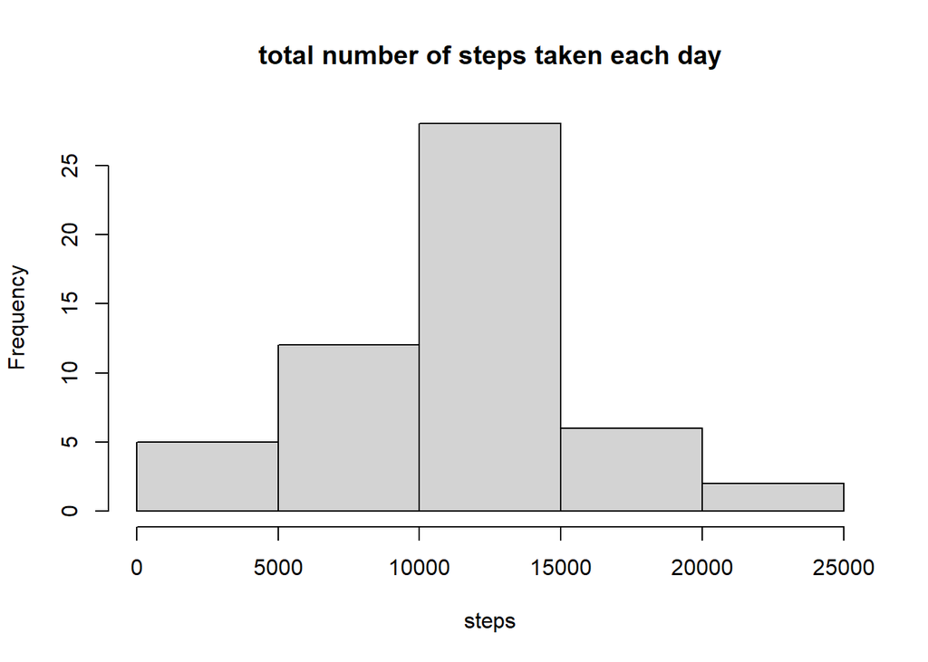

```r
hist(activity$steps, main = "total number of steps taken each day", xlab = "steps")
```

```r
summary(activity)
```

```
##       date                steps
##  Min.   :2012-10-02   Min.   :   41
##  1st Qu.:2012-10-16   1st Qu.: 8841
##  Median :2012-10-29   Median :10765
##  Mean   :2012-10-30   Mean   :10766
##  3rd Qu.:2012-11-16   3rd Qu.:13294
##  Max.   :2012-11-29   Max.   :21194
```

## What is the average daily activity pattern?

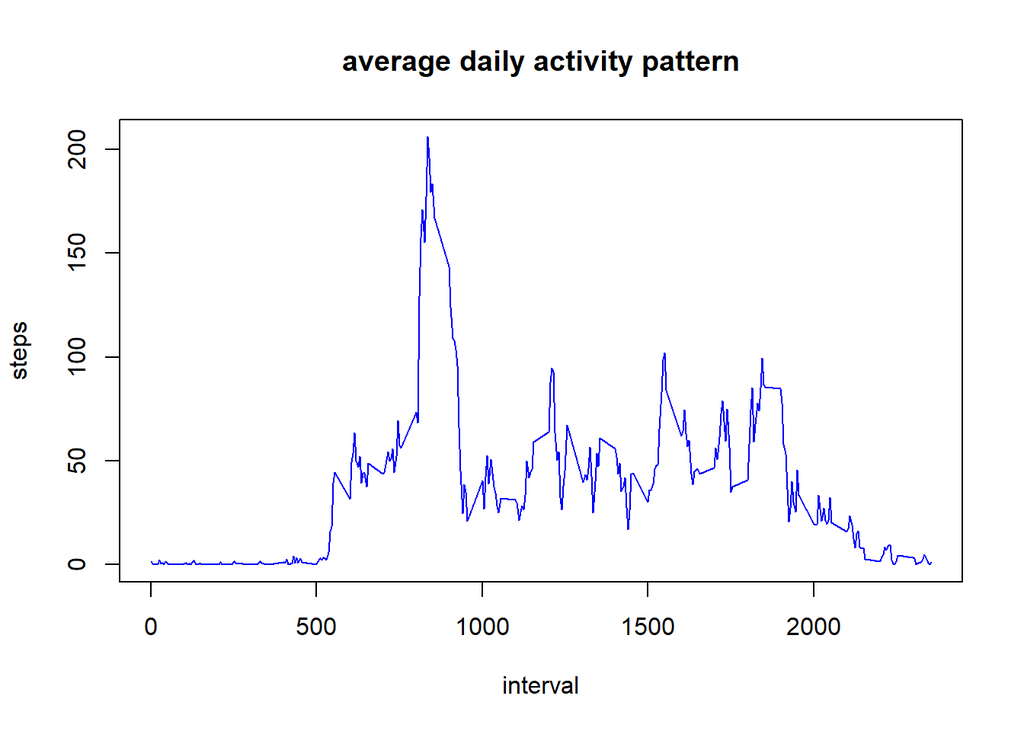

```r
activity_interval <- aggregate(steps ~ interval, df, mean)

plot(activity_interval$interval,activity_interval$steps, type = "l",
     main = "average daily activity pattern", xlab = "interval", ylab = "steps",
     col = "blue")
```

Identifying the interval with maximum steps

```r
activity_interval[which.max(activity_interval$steps),]
```

```
##     interval    steps
## 104      835 206.1698
```

## Imputing missing values.

I have used dplyr to make new column with the data of the total steps each day. And then replaced the NA with the average steps. for a day.

```r
sum(is.na(df.na))
```

```
## [1] 2304
```

```r
df_imputed <-df.na %>%
             mutate(date = as.Date(date, format = "%Y-%m-%d")) %>%
             group_by(date) %>%
             mutate(sum_steps = sum(steps))

df_imputed$sum_steps[which(is.na(df_imputed$sum_steps))] = mean(df_imputed$sum_steps,na.rm = T)
```

Making a new histogram with the imputed data frame

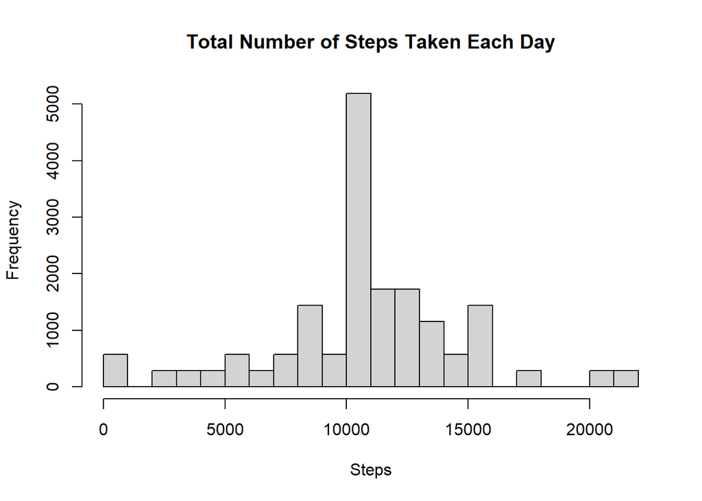

```r
hist(df_imputed$sum_steps, main = "Total Number of Steps Taken Each Day", xlab = "Steps", breaks = 30)
```

## Are there differences in activity patterns between weekdays and weekends?

Preparing the data

The first thing we want to do is use the weekend function to transform the dates to the names of each day. Then we will replace each day with the corresponding label weekday or weekend.

```r
df_imputed$days <- weekdays(df_imputed$date)
df_imputed$days <- ifelse(df_imputed$days=="Saturday" | df_imputed$days=="Sunday",
                          "weekend","weekday")
```

```r
df_imputed_intervals <-aggregate(steps~interval+days,data=df_imputed,FUN=mean,na.action=na.omit)
```

Plotting the result

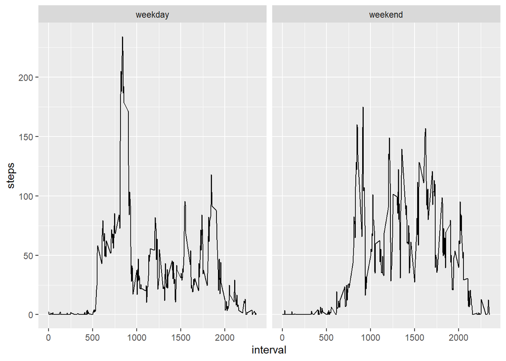

```r
g <- ggplot(df_imputed_intervals, aes(interval,steps))
g + facet_wrap(~days) + geom_line()
```